# LSTM Assignment - 14 [Model 1 and 2]

```python
# Importing all necessary files
%matplotlib inline
import warnings
warnings.filterwarnings("ignore")

import sqlite3
import pandas as pd
import numpy as np
import nltk
import string
import matplotlib.pyplot as plt
import seaborn as sns
from pickle import load,dump

from nltk.stem.porter import PorterStemmer

import re
# Tutorial about Python regular expressions: https://pymotw.com/2/re/
import string
from nltk.corpus import stopwords
from nltk.stem import PorterStemmer
from nltk.stem.wordnet import WordNetLemmatizer
from sklearn.metrics import roc_auc_score


import pickle
from tqdm import tqdm
import os

from plotly import plotly
import plotly.offline as offline
import plotly.graph_objs as go
offline.init_notebook_mode()
from collections import Counter
```

### Model 1

[figure not shown]

```python
# keras imports
from sklearn.preprocessing import StandardScaler
from keras.layers import BatchNormalization,Dense,Dropout,Input,Embedding,LSTM,Flatten
from keras.layers import Conv1D
from keras.models import Model,Sequential
from keras.layers.merge import concatenate
from keras.preprocessing.sequence import pad_sequences
```

```python
project_data = pd.read_csv('train_data.csv')
resource_data = pd.read_csv('resources.csv')
```

```python
project_data.isnull().sum()
```

```
Unnamed: 0                                           0
id                                                   0
teacher_id                                           0
teacher_prefix                                       3
school_state                                         0
project_submitted_datetime                           0
project_grade_category                               0
project_subject_categories                           0
project_subject_subcategories                        0
project_title                                        0
project_essay_1                                      0
project_essay_2                                      0
project_essay_3                                 105490
project_essay_4                                 105490
project_resource_summary                             0
teacher_number_of_previously_posted_projects         0
project_is_approved                                  0
dtype: int64
```

```python
#filling 3 null teacher prefix values with Teacher

project_data["teacher_prefix"].fillna("Teacher",inplace = True)
project_data.isnull().sum()
```

```
Unnamed: 0                                           0
id                                                   0
teacher_id                                           0
teacher_prefix                                       0
school_state                                         0
project_submitted_datetime                           0
project_grade_category                               0
project_subject_categories                           0
project_subject_subcategories                        0
project_title                                        0
project_essay_1                                      0
project_essay_2                                      0
project_essay_3                                 105490
project_essay_4                                 105490
project_resource_summary                             0
teacher_number_of_previously_posted_projects         0
project_is_approved                                  0
dtype: int64
```

```python
# merge two column text dataframe:
project_data["essay"] = project_data["project_essay_1"].map(str) +\
                        project_data["project_essay_2"].map(str) + \
                        project_data["project_essay_3"].map(str) + \
                        project_data["project_essay_4"].map(str)
```

```python
# comibining total text_data
project_data["combine"] = project_data["essay"] + project_data["project_title"]
```

```python
price_data = resource_data.groupby('id').agg({'price':'sum', 'quantity':'sum'}).reset_index()
project_data = pd.merge(project_data, price_data, on='id', how='left')
```

```python
project_data.info()
```

```
<class 'pandas.core.frame.DataFrame'>
Int64Index: 109248 entries, 0 to 109247
Data columns (total 21 columns):
Unnamed: 0                                      109248 non-null int64
id                                              109248 non-null object
teacher_id                                      109248 non-null object
teacher_prefix                                  109248 non-null object
school_state                                    109248 non-null object
project_submitted_datetime                      109248 non-null object
project_grade_category                          109248 non-null object
project_subject_categories                      109248 non-null object
project_subject_subcategories                   109248 non-null object
project_title                                   109248 non-null object
project_essay_1                                 109248 non-null object
project_essay_2                                 109248 non-null object
project_essay_3                                 3758 non-null object
project_essay_4                                 3758 non-null object
project_resource_summary                        109248 non-null object
teacher_number_of_previously_posted_projects    109248 non-null int64
project_is_approved                             109248 non-null int64
essay                                           109248 non-null object
combine                                         109248 non-null object
price                                           109248 non-null float64
quantity                                        109248 non-null int64
dtypes: float64(1), int64(4), object(16)
memory usage: 18.3+ MB
```

```python
project_data.columns
```

```
Index(['Unnamed: 0', 'id', 'teacher_id', 'teacher_prefix', 'school_state',
       'project_submitted_datetime', 'project_grade_category',
       'project_subject_categories', 'project_subject_subcategories',
       'project_title', 'project_essay_1', 'project_essay_2',
       'project_essay_3', 'project_essay_4', 'project_resource_summary',
       'teacher_number_of_previously_posted_projects', 'project_is_approved',
       'essay', 'combine', 'price', 'quantity'],
      dtype='object')
```

```python
from sklearn.utils import resample
p_d = resample(project_data)


#splitting data as 30% to test
from sklearn.model_selection import train_test_split
from sklearn.feature_extraction.text import CountVectorizer

p_d = resample(p_d,n_samples = 60000)

y = p_d["project_is_approved"]
X = p_d.drop("project_is_approved",axis = 1)
X_train, X_test, y_train, y_test = train_test_split(X, y, test_size=1/6, random_state=42)
X_train, X_val, y_train, y_val = train_test_split(X_train, y_train, test_size=1/5, random_state=42)


print(X_train.shape," ",y_train.shape)
print(X_test.shape," ",y_test.shape)
print(X_val.shape," ",y_val.shape)
```

```
(40000, 20)   (40000,)
(10000, 20)   (10000,)
(10000, 20)   (10000,)
```

### Preprocessing Text Data

```python
#using function and stopwords form assignemnt

import re

def decontracted(phrase):
    # specific
    phrase = re.sub(r"won't", "will not", phrase)
    phrase = re.sub(r"can\'t", "can not", phrase)

    # general
    phrase = re.sub(r"n\'t", " not", phrase)
    phrase = re.sub(r"\'re", " are", phrase)
    phrase = re.sub(r"\'s", " is", phrase)
    phrase = re.sub(r"\'d", " would", phrase)
    phrase = re.sub(r"\'ll", " will", phrase)
    phrase = re.sub(r"\'t", " not", phrase)
    phrase = re.sub(r"\'ve", " have", phrase)
    phrase = re.sub(r"\'m", " am", phrase)
    return phrase

# we are removing the words from the stop words list: 'no', 'nor', 'not'
stopwords= ['i', 'me', 'my', 'myself', 'we', 'our', 'ours', 'ourselves', 'you', "you're", "you've",\
            "you'll", "you'd", 'your', 'yours', 'yourself', 'yourselves', 'he', 'him', 'his', 'himself', \
            'she', "she's", 'her', 'hers', 'herself', 'it', "it's", 'its', 'itself', 'they', 'them', 'their',\
            'theirs', 'themselves', 'what', 'which', 'who', 'whom', 'this', 'that', "that'll", 'these', 'those', \
            'am', 'is', 'are', 'was', 'were', 'be', 'been', 'being', 'have', 'has', 'had', 'having', 'do', 'does', \
            'did', 'doing', 'a', 'an', 'the', 'and', 'but', 'if', 'or', 'because', 'as', 'until', 'while', 'of', \
            'at', 'by', 'for', 'with', 'about', 'against', 'between', 'into', 'through', 'during', 'before', 'after',\
            'above', 'below', 'to', 'from', 'up', 'down', 'in', 'out', 'on', 'off', 'over', 'under', 'again', 'further',\
            'then', 'once', 'here', 'there', 'when', 'where', 'why', 'how', 'all', 'any', 'both', 'each', 'few', 'more',\
            'most', 'other', 'some', 'such', 'only', 'own', 'same', 'so', 'than', 'too', 'very', \
            's', 't', 'can', 'will', 'just', 'don', "don't", 'should', "should've", 'now', 'd', 'll', 'm', 'o', 're', \
            've', 'y', 'ain', 'aren', "aren't", 'couldn', "couldn't", 'didn', "didn't", 'doesn', "doesn't", 'hadn',\
            "hadn't", 'hasn', "hasn't", 'haven', "haven't", 'isn', "isn't", 'ma', 'mightn', "mightn't", 'mustn',\
            "mustn't", 'needn', "needn't", 'shan', "shan't", 'shouldn', "shouldn't", 'wasn', "wasn't", 'weren', "weren't", \
            'won', "won't", 'wouldn', "wouldn't"]
```

```python
from tqdm import tqdm

#for train data
preprocessed_combine = []
# tqdm is for printing the status bar
for sentance in tqdm(X_train['combine'].values):
    sent = decontracted(sentance)
    sent = sent.replace('\\r', ' ')
    sent = sent.replace('\\"', ' ')
    sent = sent.replace('\\n', ' ')
    sent = re.sub('[^A-Za-z0-9]+', ' ', sent)
    # https://gist.github.com/sebleier/554280
    sent = ' '.join(e for e in sent.split() if e not in stopwords)
    preprocessed_combine.append(sent.lower().strip())

test_preprocessed_combine = []
# tqdm is for printing the status bar
for sentance in tqdm(X_test['combine'].values):
    sent = decontracted(sentance)
    sent = sent.replace('\\r', ' ')
    sent = sent.replace('\\"', ' ')
    sent = sent.replace('\\n', ' ')
    sent = re.sub('[^A-Za-z0-9]+', ' ', sent)
    # https://gist.github.com/sebleier/554280
    sent = ' '.join(e for e in sent.split() if e not in stopwords)
    test_preprocessed_combine.append(sent.lower().strip())

val_preprocessed_combine = []
# tqdm is for printing the status bar
for sentance in tqdm(X_val['combine'].values):
    sent = decontracted(sentance)
    sent = sent.replace('\\r', ' ')
    sent = sent.replace('\\"', ' ')
    sent = sent.replace('\\n', ' ')
    sent = re.sub('[^A-Za-z0-9]+', ' ', sent)
    # https://gist.github.com/sebleier/554280
    sent = ' '.join(e for e in sent.split() if e not in stopwords)
    val_preprocessed_combine.append(sent.lower().strip())
```

```
100%|█████████████████████████████████████████████████████████████████████████████████████████████████████████████████████████████████████████████████████████████████████| 40000/40000 [00:26<00:00, 1536.79it/s]
100%|█████████████████████████████████████████████████████████████████████████████████████████████████████████████████████████████████████████████████████████████████████| 10000/10000 [00:06<00:00, 1536.26it/s]
100%|█████████████████████████████████████████████████████████████████████████████████████████████████████████████████████████████████████████████████████████████████████| 10000/10000 [00:06<00:00, 1533.90it/s]
```

#### Embedding Essay

```python
from keras.preprocessing.text import Tokenizer

# considering all the words.
token = Tokenizer()

# fitting on train data.
token.fit_on_texts(preprocessed_combine)
```

**Caution:**

Tokenizer considers only top words provided by num_words while converting to sequences. i.e. if word is not present the it skips the word. But token.index_word keeps all the record of words in whole vocabulary.So, remoove unnecessary words while using token.index_words as a dictionary.

```python
# index to words are assigned according to frequency. i.e the most frequent word has index of 1
# MAX_WORDS = 47743
ix_to_word = token.index_word
MAX_WORDS = len(ix_to_word)+1

print("Total words considering for this assignment {}".format(MAX_WORDS))
```

```
Total words considering for this assignment 38180
```

```python
for k in list(ix_to_word):
    if k>=MAX_WORDS:
        ix_to_word.pop(k, None)

word_to_ix = dict()
for k,v in ix_to_word.items():
    word_to_ix[v] = k
```

```python
print(len(word_to_ix))
print(len(ix_to_word))
```

```
38179
38179
```

```python
combine_sequence = token.texts_to_sequences(preprocessed_combine)
val_combine_sequence = token.texts_to_sequences(val_preprocessed_combine)
test_combine_sequence = token.texts_to_sequences(test_preprocessed_combine)

print(len(combine_sequence))
print(len(val_combine_sequence))
print(len(test_combine_sequence))
```

```
40000
10000
10000
```

```python
sequence_length_1 = 335

combine_sequence = pad_sequences(combine_sequence,maxlen=sequence_length_1,padding="post")
val_combine_sequence = pad_sequences(val_combine_sequence,maxlen=sequence_length_1,padding="post")
test_combine_sequence = pad_sequences(test_combine_sequence,maxlen=sequence_length_1,padding="post")

print(combine_sequence.shape)
print(test_combine_sequence.shape)
print(val_combine_sequence.shape)
```

```
(40000, 335)
(10000, 335)
(10000, 335)
```

```python
MAX_LENGTH = sequence_length_1
print("Maximum sequence length is {}".format(MAX_LENGTH))
print(combine_sequence.shape)
```

```
Maximum sequence length is 335
(40000, 335)
```

```python
# make sure you have the glove_vectors file
with open('glove_vectors', 'rb') as f:
    glove = load(f)
    glove_words =  set(glove.keys())
```

```python
EMBEDDING_SIZE = 300
VOCAB_SIZE = MAX_WORDS

# Get 300-dim dense vector for each of the words in vocabulary
embedding_matrix = np.zeros((VOCAB_SIZE,EMBEDDING_SIZE))
embedding_matrix.shape
```

```
(38180, 300)
```

```python
# code for embedding matrix. considering top 5000 words and using already present glove vectors

# Get 300-dim dense vector for each of the words in vocabulary
embedding_matrix = np.zeros(((VOCAB_SIZE),EMBEDDING_SIZE))

for word, i in word_to_ix.items():
    embedding_vector = np.zeros(300)
    if word in glove_words:
        embedding_vector = glove[word]
        embedding_matrix[i] = embedding_vector
    else:
        # Words not found in the embedding index will be all zeros
        embedding_matrix[i] = embedding_vector
```

```python
embedding_matrix.shape
```

```
(38180, 300)
```

```python
# save the embedding matrix to file
with open("embedding_matrix.pkl","wb") as f:
    dump(embedding_matrix,f)
```

*Functional API for Essay*

```python
# functional api for essay
LSTM_units = 4

input_ess = Input(shape=(MAX_LENGTH,))
em1 = Embedding(MAX_WORDS,EMBEDDING_SIZE,input_length=MAX_LENGTH)(input_ess)
lstm = LSTM(LSTM_units,input_shape = (1,MAX_LENGTH), return_sequences=True,)(em1)
flt_ess  = Flatten()(lstm)
```

```
WARNING:tensorflow:From C:\Users\rdbz3b\AppData\Local\Continuum\anaconda3\lib\site-packages\tensorflow\python\framework\op_def_library.py:263: colocate_with (from tensorflow.python.framework.ops) is deprecated and will be removed in a future version.
Instructions for updating:
Colocations handled automatically by placer.
```

### Categorical Embedding

```python
def generate_sequence(category , category_dict,df):

    """
    This function takes i/p as category name and its dictionary.

    convert them to sequences using pad_sequences from keras.

    Returns MAX_Length,VOCAB_SIZE and normalized_sequence for give category

    """
    word_to_ix = dict()
    ix_to_word = dict()

    # sorting dictionary in descending order
    category_dict = dict(sorted(category_dict.items(), key=lambda kv: kv[1],reverse = True))

    count = 1
    for k in category_dict.keys():
        ix_to_word[count] = k
        count += 1

    for k,v in ix_to_word.items():
        word_to_ix[v] = k

    print(word_to_ix)
    print("*"*50)
    print(ix_to_word)

    category_sequence = []
    for ec in df[category].values:
        temp = []
        for c in ec.split():
            temp.append(word_to_ix.get(c,0))
        category_sequence.append(temp)

    # conveting sequnce to same length using pad sequence in keras
    category_sequence = pad_sequences(category_sequence,padding="post",dtype="float32")
    #normalized_sequence = normalize(category_sequence)

    MAX_LENGTH = category_sequence.shape[1]
    VOCAB_SIZE = len(word_to_ix) + 1

    print("\nMaximum length of sequence is {}".format(MAX_LENGTH))
    print("\nVocabulary size is {}".format(VOCAB_SIZE))
    print("\nShape of {} category sequence is {}".format(category,category_sequence.shape))

    return category_sequence,MAX_LENGTH,VOCAB_SIZE
```

For categories and sub-categories i/p sequence can be vary.

for e.g. category can be [History Math].

So we are converting categories to max length sequence

*project categories*

```python
catogories = list(X_train['project_subject_categories'].values)

cat_list = []
for i in catogories:
    temp = ""
    for j in i.split(','):
        if 'The' in j.split():
            j=j.replace('The','')
        j = j.replace(' ','')
        temp+=j.strip()+" "
        temp = temp.replace('&','_')
    cat_list.append(temp.strip())

X_train['clean_categories'] = cat_list
X_train.drop(['project_subject_categories'], axis=1, inplace=True)

from collections import Counter
my_counter = Counter()
for word in X_train['clean_categories'].values:
    my_counter.update(word.split())

cat_dict = dict(my_counter)
sorted_cat_dict = dict(sorted(cat_dict.items(), key=lambda kv: kv[1]))




# project subject categories for test data

catogories = list(X_test['project_subject_categories'].values)

cat_list = []
for i in catogories:
    temp = ""
    for j in i.split(','):
        if 'The' in j.split():
            j=j.replace('The','')
        j = j.replace(' ','')
        temp+=j.strip()+" "
        temp = temp.replace('&','_')
    cat_list.append(temp.strip())

X_test['clean_categories'] = cat_list
X_test.drop(['project_subject_categories'], axis=1, inplace=True)


# project subject categories for val data

catogories = list(X_val['project_subject_categories'].values)

cat_list = []
for i in catogories:
    temp = ""
    for j in i.split(','):
        if 'The' in j.split():
            j=j.replace('The','')
        j = j.replace(' ','')
        temp+=j.strip()+" "
        temp = temp.replace('&','_')
    cat_list.append(temp.strip())

X_val['clean_categories'] = cat_list
X_val.drop(['project_subject_categories'], axis=1, inplace=True)
```

```python
category_sequence,MAX_LENGTH,VOCAB_SIZE = generate_sequence("clean_categories",sorted_cat_dict,X_train)
test_category_sequence,MAX_LENGTH,VOCAB_SIZE = generate_sequence("clean_categories",sorted_cat_dict,X_test)
val_category_sequence,MAX_LENGTH,VOCAB_SIZE = generate_sequence("clean_categories",sorted_cat_dict,X_val)
```

```
{'Literacy_Language': 1, 'Math_Science': 2, 'Health_Sports': 3, 'SpecialNeeds': 4, 'AppliedLearning': 5, 'Music_Arts': 6, 'History_Civics': 7, 'Warmth': 8, 'Care_Hunger': 9}
{1: 'Literacy_Language', 2: 'Math_Science', 3: 'Health_Sports', 4: 'SpecialNeeds', 5: 'AppliedLearning', 6: 'Music_Arts', 7: 'History_Civics', 8: 'Warmth', 9: 'Care_Hunger'}

Maximum length of sequence is 3

Vocabulary size is 10

Shape of clean_categories category sequence is (40000, 3)
{'Literacy_Language': 1, 'Math_Science': 2, 'Health_Sports': 3, 'SpecialNeeds': 4, 'AppliedLearning': 5, 'Music_Arts': 6, 'History_Civics': 7, 'Warmth': 8, 'Care_Hunger': 9}
{1: 'Literacy_Language', 2: 'Math_Science', 3: 'Health_Sports', 4: 'SpecialNeeds', 5: 'AppliedLearning', 6: 'Music_Arts', 7: 'History_Civics', 8: 'Warmth', 9: 'Care_Hunger'}

Maximum length of sequence is 3

Vocabulary size is 10

Shape of clean_categories category sequence is (10000, 3)
{'Literacy_Language': 1, 'Math_Science': 2, 'Health_Sports': 3, 'SpecialNeeds': 4, 'AppliedLearning': 5, 'Music_Arts': 6, 'History_Civics': 7, 'Warmth': 8, 'Care_Hunger': 9}
{1: 'Literacy_Language', 2: 'Math_Science', 3: 'Health_Sports', 4: 'SpecialNeeds', 5: 'AppliedLearning', 6: 'Music_Arts', 7: 'History_Civics', 8: 'Warmth', 9: 'Care_Hunger'}

Maximum length of sequence is 3

Vocabulary size is 10

Shape of clean_categories category sequence is (10000, 3)
```

```python
# Embdeeing layer for category

input_pc = Input(shape=(MAX_LENGTH,))
em = Embedding(VOCAB_SIZE,10,input_length=MAX_LENGTH)(input_pc)
flt_pc  = Flatten()(em)

print("Output will contain shape of {}x{}".format(MAX_LENGTH,10))
```

```
Output will contain shape of 3x10
```

*project subject sub_categories*

```python
sub_catogories = list(X_train['project_subject_subcategories'].values)
sub_cat_list = []
for i in sub_catogories:
    temp = ""
    for j in i.split(','):
        if 'The' in j.split(): # this will split each of the catogory based on space "Math & Science"=> "Math","&", "Science"
            j=j.replace('The','') # if we have the words "The" we are going to replace it with ''(i.e removing 'The')
        j = j.replace(' ','')
        temp +=j.strip()+" "
        temp = temp.replace('&','_')
    sub_cat_list.append(temp.strip())

X_train['clean_subcategories'] = sub_cat_list
X_train.drop(['project_subject_subcategories'], axis=1, inplace=True)

# count of all the words in corpus python: https://stackoverflow.com/a/22898595/4084039
my_counter = Counter()
for word in X_train['clean_subcategories'].values:
    my_counter.update(word.split())

sub_cat_dict = dict(my_counter)
sorted_sub_cat_dict = dict(sorted(sub_cat_dict.items(), key=lambda kv: kv[1]))




sub_catogories = list(X_test['project_subject_subcategories'].values)
sub_cat_list = []
for i in sub_catogories:
    temp = ""
    for j in i.split(','):
        if 'The' in j.split(): # this will split each of the catogory based on space "Math & Science"=> "Math","&", "Science"
            j=j.replace('The','') # if we have the words "The" we are going to replace it with ''(i.e removing 'The')
        j = j.replace(' ','')
        temp +=j.strip()+" "
        temp = temp.replace('&','_')
    sub_cat_list.append(temp.strip())

X_test['clean_subcategories'] = sub_cat_list
X_test.drop(['project_subject_subcategories'], axis=1, inplace=True)

sub_catogories = list(X_val['project_subject_subcategories'].values)
sub_cat_list = []
for i in sub_catogories:
    temp = ""
    for j in i.split(','):
        if 'The' in j.split(): # this will split each of the catogory based on space "Math & Science"=> "Math","&", "Science"
            j=j.replace('The','') # if we have the words "The" we are going to replace it with ''(i.e removing 'The')
        j = j.replace(' ','')
        temp +=j.strip()+" "
        temp = temp.replace('&','_')
    sub_cat_list.append(temp.strip())

X_val['clean_subcategories'] = sub_cat_list
X_val.drop(['project_subject_subcategories'], axis=1, inplace=True)
```

```python
subcategory_sequence,MAX_LENGTH,VOCAB_SIZE = generate_sequence("clean_subcategories",sorted_sub_cat_dict,X_train)
val_subcategory_sequence,MAX_LENGTH,VOCAB_SIZE = generate_sequence("clean_subcategories",sorted_sub_cat_dict,X_val)
test_subcategory_sequence,MAX_LENGTH,VOCAB_SIZE = generate_sequence("clean_subcategories",sorted_sub_cat_dict,X_test)
```

```
{'Literacy': 1, 'Mathematics': 2, 'Literature_Writing': 3, 'SpecialNeeds': 4, 'AppliedSciences': 5, 'Health_Wellness': 6, 'VisualArts': 7, 'EnvironmentalScience': 8, 'Gym_Fitness': 9, 'EarlyDevelopment': 10, 'Health_LifeScience': 11, 'ESL': 12, 'Music': 13, 'History_Geography': 14, 'College_CareerPr…
{1: 'Literacy', 2: 'Mathematics', 3: 'Literature_Writing', 4: 'SpecialNeeds', 5: 'AppliedSciences', 6: 'Health_Wellness', 7: 'VisualArts', 8: 'EnvironmentalScience', 9: 'Gym_Fitness', 10: 'EarlyDevelopment', 11: 'Health_LifeScience', 12: 'ESL', 13: 'Music', 14: 'History_Geography', 15: 'College_Care…

Maximum length of sequence is 3

Vocabulary size is 31

Shape of clean_subcategories category sequence is (40000, 3)
{'Literacy': 1, 'Mathematics': 2, 'Literature_Writing': 3, 'SpecialNeeds': 4, 'AppliedSciences': 5, 'Health_Wellness': 6, 'VisualArts': 7, 'EnvironmentalScience': 8, 'Gym_Fitness': 9, 'EarlyDevelopment': 10, 'Health_LifeScience': 11, 'ESL': 12, 'Music': 13, 'History_Geography': 14, 'College_CareerPr…
{1: 'Literacy', 2: 'Mathematics', 3: 'Literature_Writing', 4: 'SpecialNeeds', 5: 'AppliedSciences', 6: 'Health_Wellness', 7: 'VisualArts', 8: 'EnvironmentalScience', 9: 'Gym_Fitness', 10: 'EarlyDevelopment', 11: 'Health_LifeScience', 12: 'ESL', 13: 'Music', 14: 'History_Geography', 15: 'College_Care…

Maximum length of sequence is 3

Vocabulary size is 31

Shape of clean_subcategories category sequence is (10000, 3)
{'Literacy': 1, 'Mathematics': 2, 'Literature_Writing': 3, 'SpecialNeeds': 4, 'AppliedSciences': 5, 'Health_Wellness': 6, 'VisualArts': 7, 'EnvironmentalScience': 8, 'Gym_Fitness': 9, 'EarlyDevelopment': 10, 'Health_LifeScience': 11, 'ESL': 12, 'Music': 13, 'History_Geography': 14, 'College_CareerPr…
{1: 'Literacy', 2: 'Mathematics', 3: 'Literature_Writing', 4: 'SpecialNeeds', 5: 'AppliedSciences', 6: 'Health_Wellness', 7: 'VisualArts', 8: 'EnvironmentalScience', 9: 'Gym_Fitness', 10: 'EarlyDevelopment', 11: 'Health_LifeScience', 12: 'ESL', 13: 'Music', 14: 'History_Geography', 15: 'College_Care…

Maximum length of sequence is 3

Vocabulary size is 31

Shape of clean_subcategories category sequence is (10000, 3)
```

```python
# Embdeeing layer for category

input_psc = Input(shape=(MAX_LENGTH,))
em = Embedding(VOCAB_SIZE,10,input_length=MAX_LENGTH)(input_psc)
flt_psc  = Flatten()(em)

print("Output will contain shape of {}x{}".format(MAX_LENGTH,10))
```

```
Output will contain shape of 3x10
```

*Teacher Prefix*

```python
#preprocessing teacher prefix
prefix = list(X_train['teacher_prefix'].values)
prefix_list = []
for i in prefix:
    temp = ""
    if "." in i:
            i=i.replace('.','')
    temp+=i.strip()+" "
    prefix_list.append(temp.strip())

X_train['clean_prefix'] = prefix_list

my_counter = Counter()
for word in X_train['clean_prefix'].values:
  my_counter.update(word.split())

prefix_dict = dict(my_counter)
sorted_prefix_dict = dict(sorted(prefix_dict.items(), key=lambda kv: kv[1]))
print(sorted_prefix_dict)


#preprocessing teacher prefix for test data
prefix = list(X_test['teacher_prefix'].values)
prefix_list = []
for i in prefix:
    temp = ""
    if "." in i:
            i=i.replace('.','')
    temp+=i.strip()+" "
    prefix_list.append(temp.strip())

X_test['clean_prefix'] = prefix_list

#preprocessing teacher prefix for val data
prefix = list(X_val['teacher_prefix'].values)
prefix_list = []
for i in prefix:
    temp = ""
    if "." in i:
            i=i.replace('.','')
    temp+=i.strip()+" "
    prefix_list.append(temp.strip())

X_val['clean_prefix'] = prefix_list
```

```
{'Dr': 1, 'Teacher': 866, 'Mr': 3775, 'Ms': 14404, 'Mrs': 20954}
```

```python
prefix_sequence,MAX_LENGTH,VOCAB_SIZE = generate_sequence("clean_prefix",sorted_prefix_dict,X_train)
val_prefix_sequence,MAX_LENGTH,VOCAB_SIZE = generate_sequence("clean_prefix",sorted_prefix_dict,X_val)
test_prefix_sequence,MAX_LENGTH,VOCAB_SIZE = generate_sequence("clean_prefix",sorted_prefix_dict,X_test)
```

```
{'Mrs': 1, 'Ms': 2, 'Mr': 3, 'Teacher': 4, 'Dr': 5}
{1: 'Mrs', 2: 'Ms', 3: 'Mr', 4: 'Teacher', 5: 'Dr'}

Maximum length of sequence is 1

Vocabulary size is 6

Shape of clean_prefix category sequence is (40000, 1)
{'Mrs': 1, 'Ms': 2, 'Mr': 3, 'Teacher': 4, 'Dr': 5}
{1: 'Mrs', 2: 'Ms', 3: 'Mr', 4: 'Teacher', 5: 'Dr'}

Maximum length of sequence is 1

Vocabulary size is 6

Shape of clean_prefix category sequence is (10000, 1)
{'Mrs': 1, 'Ms': 2, 'Mr': 3, 'Teacher': 4, 'Dr': 5}
{1: 'Mrs', 2: 'Ms', 3: 'Mr', 4: 'Teacher', 5: 'Dr'}

Maximum length of sequence is 1

Vocabulary size is 6

Shape of clean_prefix category sequence is (10000, 1)
```

```python
np.unique(prefix_sequence)
```

```
array([1., 2., 3., 4., 5.], dtype=float32)
```

```python
# Embdeeing layer for grade

input_tp = Input(shape=(1,))
em = Embedding(VOCAB_SIZE,10,input_length=MAX_LENGTH)(input_tp)
flt_tp  = Flatten()(em)
```

*Grade Category*

```python
grade = list(X_train['project_grade_category'].values)
grade_list = []
for i in grade:
    temp = ""
    if "Grades" in i:
      i = i.replace("Grades","")
    if "6-8" in i:
      i = i.replace("6-8","six_eight")
    if "3-5" in i:
      i = i.replace("3-5","three_five")
    if "9-12" in i:
      i = i.replace("9-12","nine_twelve")
    if "PreK-2" in i:
      i = i.replace("PreK-2","prek_two")
    temp+=i.strip()+" "
    grade_list.append(temp.strip())

X_train['clean_grade'] = grade_list

my_counter = Counter()
for word in X_train['clean_grade'].values:
  my_counter.update(word.split())

grade_dict = dict(my_counter)
sorted_grade_dict = dict(sorted(grade_dict.items(), key=lambda kv: kv[1]))
print(sorted_grade_dict)



# preprocessing of grade category for test data

grade = list(X_test['project_grade_category'].values)
grade_list = []
for i in grade:
    temp = ""
    if "Grades" in i:
      i = i.replace("Grades","")
    if "6-8" in i:
      i = i.replace("6-8","six_eight")
    if "3-5" in i:
      i = i.replace("3-5","three_five")
    if "9-12" in i:
      i = i.replace("9-12","nine_twelve")
    if "PreK-2" in i:
      i = i.replace("PreK-2","prek_two")
    temp+=i.strip()+" "
    grade_list.append(temp.strip())

X_test['clean_grade'] = grade_list

# preprocessing of grade category for val data

grade = list(X_val['project_grade_category'].values)
grade_list = []
for i in grade:
    temp = ""
    if "Grades" in i:
      i = i.replace("Grades","")
    if "6-8" in i:
      i = i.replace("6-8","six_eight")
    if "3-5" in i:
      i = i.replace("3-5","three_five")
    if "9-12" in i:
      i = i.replace("9-12","nine_twelve")
    if "PreK-2" in i:
      i = i.replace("PreK-2","prek_two")
    temp+=i.strip()+" "
    grade_list.append(temp.strip())

X_val['clean_grade'] = grade_list
```

```
{'nine_twelve': 3954, 'six_eight': 6125, 'three_five': 13666, 'prek_two': 16255}
```

```python
grade_sequence,MAX_LENGTH,VOCAB_SIZE = generate_sequence("clean_grade",sorted_grade_dict,X_train)
val_grade_sequence,MAX_LENGTH,VOCAB_SIZE = generate_sequence("clean_grade",sorted_grade_dict,X_val)
test_grade_sequence,MAX_LENGTH,VOCAB_SIZE = generate_sequence("clean_grade",sorted_grade_dict,X_test)
```

```
{'prek_two': 1, 'three_five': 2, 'six_eight': 3, 'nine_twelve': 4}
{1: 'prek_two', 2: 'three_five', 3: 'six_eight', 4: 'nine_twelve'}

Maximum length of sequence is 1

Vocabulary size is 5

Shape of clean_grade category sequence is (40000, 1)
{'prek_two': 1, 'three_five': 2, 'six_eight': 3, 'nine_twelve': 4}
{1: 'prek_two', 2: 'three_five', 3: 'six_eight', 4: 'nine_twelve'}

Maximum length of sequence is 1

Vocabulary size is 5

Shape of clean_grade category sequence is (10000, 1)
{'prek_two': 1, 'three_five': 2, 'six_eight': 3, 'nine_twelve': 4}
{1: 'prek_two', 2: 'three_five', 3: 'six_eight', 4: 'nine_twelve'}

Maximum length of sequence is 1

Vocabulary size is 5

Shape of clean_grade category sequence is (10000, 1)
```

```python
# Embdeeing layer for grade

print("Input vocab size for grade category is {}".format(VOCAB_SIZE))

input_gc = Input(shape=(1,))
em = Embedding(VOCAB_SIZE,10,input_length=MAX_LENGTH)(input_gc)
flt_gc  = Flatten()(em)
```

```
Input vocab size for grade category is 5
```

*School State*

```python
#no need of preprocessing on school state

state = X_train["school_state"].value_counts()
sorted_state = dict(state)
sorted_state_dict = dict(sorted(sorted_state.items(), key=lambda kv: kv[1]))
X_train["clean_state"] = X_train["school_state"]
print(sorted_state_dict)

#similarly for X_test
X_test["clean_state"] = X_test["school_state"]

#similarly for X_val
X_val["clean_state"] = X_val["school_state"]
```

```
{'VT': 25, 'WY': 34, 'ND': 52, 'MT': 91, 'SD': 94, 'NE': 101, 'RI': 106, 'AK': 110, 'NH': 143, 'DE': 149, 'WV': 175, 'NM': 183, 'DC': 196, 'ME': 196, 'HI': 200, 'KS': 229, 'IA': 255, 'ID': 274, 'CO': 408, 'AR': 422, 'KY': 428, 'MN': 439, 'OR': 479, 'MS': 482, 'NV': 500, 'MD': 546, 'UT': 583, 'CT': 6…
```

```python
state_sequence,MAX_LENGTH,VOCAB_SIZE = generate_sequence("clean_state",sorted_state_dict,X_train)
val_state_sequence,MAX_LENGTH,VOCAB_SIZE = generate_sequence("clean_state",sorted_state_dict,X_val)
test_state_sequence,MAX_LENGTH,VOCAB_SIZE = generate_sequence("clean_state",sorted_state_dict,X_test)
```

```
{'CA': 1, 'TX': 2, 'NY': 3, 'FL': 4, 'NC': 5, 'IL': 6, 'SC': 7, 'GA': 8, 'PA': 9, 'MI': 10, 'IN': 11, 'OH': 12, 'LA': 13, 'MO': 14, 'MA': 15, 'WA': 16, 'NJ': 17, 'OK': 18, 'AZ': 19, 'VA': 20, 'TN': 21, 'WI': 22, 'AL': 23, 'CT': 24, 'UT': 25, 'MD': 26, 'NV': 27, 'MS': 28, 'OR': 29, 'MN': 30, 'KY': 31…
{1: 'CA', 2: 'TX', 3: 'NY', 4: 'FL', 5: 'NC', 6: 'IL', 7: 'SC', 8: 'GA', 9: 'PA', 10: 'MI', 11: 'IN', 12: 'OH', 13: 'LA', 14: 'MO', 15: 'MA', 16: 'WA', 17: 'NJ', 18: 'OK', 19: 'AZ', 20: 'VA', 21: 'TN', 22: 'WI', 23: 'AL', 24: 'CT', 25: 'UT', 26: 'MD', 27: 'NV', 28: 'MS', 29: 'OR', 30: 'MN', 31: 'KY'…

Maximum length of sequence is 1

Vocabulary size is 52

Shape of clean_state category sequence is (40000, 1)
{'CA': 1, 'TX': 2, 'NY': 3, 'FL': 4, 'NC': 5, 'IL': 6, 'SC': 7, 'GA': 8, 'PA': 9, 'MI': 10, 'IN': 11, 'OH': 12, 'LA': 13, 'MO': 14, 'MA': 15, 'WA': 16, 'NJ': 17, 'OK': 18, 'AZ': 19, 'VA': 20, 'TN': 21, 'WI': 22, 'AL': 23, 'CT': 24, 'UT': 25, 'MD': 26, 'NV': 27, 'MS': 28, 'OR': 29, 'MN': 30, 'KY': 31…
{1: 'CA', 2: 'TX', 3: 'NY', 4: 'FL', 5: 'NC', 6: 'IL', 7: 'SC', 8: 'GA', 9: 'PA', 10: 'MI', 11: 'IN', 12: 'OH', 13: 'LA', 14: 'MO', 15: 'MA', 16: 'WA', 17: 'NJ', 18: 'OK', 19: 'AZ', 20: 'VA', 21: 'TN', 22: 'WI', 23: 'AL', 24: 'CT', 25: 'UT', 26: 'MD', 27: 'NV', 28: 'MS', 29: 'OR', 30: 'MN', 31: 'KY'…

Maximum length of sequence is 1

Vocabulary size is 52

Shape of clean_state category sequence is (10000, 1)
{'CA': 1, 'TX': 2, 'NY': 3, 'FL': 4, 'NC': 5, 'IL': 6, 'SC': 7, 'GA': 8, 'PA': 9, 'MI': 10, 'IN': 11, 'OH': 12, 'LA': 13, 'MO': 14, 'MA': 15, 'WA': 16, 'NJ': 17, 'OK': 18, 'AZ': 19, 'VA': 20, 'TN': 21, 'WI': 22, 'AL': 23, 'CT': 24, 'UT': 25, 'MD': 26, 'NV': 27, 'MS': 28, 'OR': 29, 'MN': 30, 'KY': 31…
{1: 'CA', 2: 'TX', 3: 'NY', 4: 'FL', 5: 'NC', 6: 'IL', 7: 'SC', 8: 'GA', 9: 'PA', 10: 'MI', 11: 'IN', 12: 'OH', 13: 'LA', 14: 'MO', 15: 'MA', 16: 'WA', 17: 'NJ', 18: 'OK', 19: 'AZ', 20: 'VA', 21: 'TN', 22: 'WI', 23: 'AL', 24: 'CT', 25: 'UT', 26: 'MD', 27: 'NV', 28: 'MS', 29: 'OR', 30: 'MN', 31: 'KY'…

Maximum length of sequence is 1

Vocabulary size is 52

Shape of clean_state category sequence is (10000, 1)
```

```python
# Embdeeing layer for school state

print("Input vocab size for school state is {}".format(VOCAB_SIZE))

input_ss = Input(shape=(MAX_LENGTH,))
em = Embedding(VOCAB_SIZE,10,input_length=MAX_LENGTH)(input_ss)
flt_ss  = Flatten()(em)
```

```
Input vocab size for school state is 52
```

### Preprocessing Numerical Feature

```python
from sklearn.preprocessing import StandardScaler


price_scalar = StandardScaler()
price_scalar.fit(project_data['price'].values.reshape(-1,1))
print(f"Mean : {price_scalar.mean_[0]}, Standard deviation : {np.sqrt(price_scalar.var_[0])}")

#train data price standardization
price_standardized = price_scalar.transform(X_train['price'].values.reshape(-1, 1))

#val data price stanardization. Fit method applied on X_train
val_price_standardized = price_scalar.transform(X_val['price'].values.reshape(-1, 1))

#test data price stanardization. Fit method applied on X_train
test_price_standardized = price_scalar.transform(X_test['price'].values.reshape(-1, 1))
```

```
Mean : 298.1193425966608, Standard deviation : 367.49634838483496
```

```python
warnings.filterwarnings("ignore")
price_scalar = StandardScaler()
price_scalar.fit(X_train["quantity"].values.reshape(-1, 1))
print(f"Mean of Quantity : {price_scalar.mean_[0]}, Standard deviation of Quantity : {np.sqrt(price_scalar.var_[0])}")

#train data quantity standardization
quantity_standardized = price_scalar.transform(X_train["quantity"].values.reshape(-1, 1))

#val data quantity stanardization. Fit method applied on X_train
val_quantity_standardized = price_scalar.transform(X_val["quantity"].values.reshape(-1, 1))


#test data quantity stanardization. Fit method applied on X_train
test_quantity_standardized = price_scalar.transform(X_test["quantity"].values.reshape(-1, 1))
```

```
Mean of Quantity : 16.9709, Standard deviation of Quantity : 25.709789053782607
```

```python
price_scalar = StandardScaler()
price_scalar.fit(X_train['teacher_number_of_previously_posted_projects'].values.reshape(-1,1))
print(f"Mean : {price_scalar.mean_[0]}, Standard deviation : {np.sqrt(price_scalar.var_[0])}")

#train data ppp standardization
number_ppp_standardized = price_scalar.transform(X_train['teacher_number_of_previously_posted_projects'].values.reshape(-1, 1))

#val data price stanardization. Fit method applied on X_train
val_number_ppp_standardized = price_scalar.transform(X_val['teacher_number_of_previously_posted_projects'].values.reshape(-1, 1))


#test data price stanardization. Fit method applied on X_train
test_number_ppp_standardized = price_scalar.transform(X_test['teacher_number_of_previously_posted_projects'].values.reshape(-1, 1))
```

```
Mean : 11.265275, Standard deviation : 28.110076559383025
```

```python
numerical_feature = np.hstack((number_ppp_standardized,quantity_standardized,price_standardized))
print(numerical_feature.shape)

val_numerical_feature = np.hstack((val_number_ppp_standardized,val_quantity_standardized,val_price_standardized))
print(val_numerical_feature.shape)

test_numerical_feature = np.hstack((test_number_ppp_standardized,test_quantity_standardized,test_price_standardized))
print(test_numerical_feature.shape)
```

```
(40000, 3)
(10000, 3)
(10000, 3)
```

### Model Preperation

*Function layer*

```python
# last funtional model for numerical features
input_nf = Input(shape=(3,))
d_nf = Dense(1,activation="relu")(input_nf)
```

*Main layer*

```python
# merging into main one
# essay + school_state + grade + teacher_prefix + category + sub_categpry + numerical
# 335+10+10+10+10+10+1 ==> 386

cnt = concatenate([flt_ess,flt_ss,flt_gc,flt_tp,flt_pc,flt_psc,d_nf])
dense = Dense(8,activation="relu")(cnt)

# dropout + dense
dp = Dropout(0.2)(dense)
dense2 = Dense(4,activation="relu")(dp)

# dropout + dense

dp = Dropout(0.2)(dense2)
dense3 = Dense(2,activation="relu")(dp)

output = Dense(1,activation="sigmoid")(dense3)
```

```
WARNING:tensorflow:From C:\Users\rdbz3b\AppData\Local\Continuum\anaconda3\lib\site-packages\keras\backend\tensorflow_backend.py:3445: calling dropout (from tensorflow.python.ops.nn_ops) with keep_prob is deprecated and will be removed in a future version.
Instructions for updating:
Please use `rate` instead of `keep_prob`. Rate should be set to `rate = 1 - keep_prob`.
```

```python
# input sequence essay + school_state + grade + teacher_prefix + category + sub_categpry + numerical
model = Model(inputs =[input_ess,input_ss,input_gc,input_tp,input_pc,input_psc,input_nf],outputs = output)
```

```python
# Freezing essay embedding_layer from training

model.layers[1].set_weights([embedding_matrix])
model.layers[1].trainable = False
```

```python
model.summary()
```

```
__________________________________________________________________________________________________
Layer (type)                    Output Shape         Param #     Connected to
==================================================================================================
input_1 (InputLayer)            (None, 335)          0
__________________________________________________________________________________________________
embedding_1 (Embedding)         (None, 335, 300)     11454000    input_1[0][0]
__________________________________________________________________________________________________
input_6 (InputLayer)            (None, 1)            0
__________________________________________________________________________________________________
input_5 (InputLayer)            (None, 1)            0
__________________________________________________________________________________________________
input_4 (InputLayer)            (None, 1)            0
__________________________________________________________________________________________________
input_2 (InputLayer)            (None, 3)            0
__________________________________________________________________________________________________
input_3 (InputLayer)            (None, 3)            0
__________________________________________________________________________________________________
lstm_1 (LSTM)                   (None, 335, 4)       4880        embedding_1[0][0]
__________________________________________________________________________________________________
embedding_6 (Embedding)         (None, 1, 10)        520         input_6[0][0]
__________________________________________________________________________________________________
embedding_5 (Embedding)         (None, 1, 10)        50          input_5[0][0]
__________________________________________________________________________________________________
embedding_4 (Embedding)         (None, 1, 10)        60          input_4[0][0]
__________________________________________________________________________________________________
embedding_2 (Embedding)         (None, 3, 10)        100         input_2[0][0]
__________________________________________________________________________________________________
embedding_3 (Embedding)         (None, 3, 10)        310         input_3[0][0]
__________________________________________________________________________________________________
input_7 (InputLayer)            (None, 3)            0
__________________________________________________________________________________________________
flatten_1 (Flatten)             (None, 1340)         0           lstm_1[0][0]
__________________________________________________________________________________________________
flatten_6 (Flatten)             (None, 10)           0           embedding_6[0][0]
__________________________________________________________________________________________________
flatten_5 (Flatten)             (None, 10)           0           embedding_5[0][0]
__________________________________________________________________________________________________
flatten_4 (Flatten)             (None, 10)           0           embedding_4[0][0]
__________________________________________________________________________________________________
flatten_2 (Flatten)             (None, 30)           0           embedding_2[0][0]
```

[output cut: 14 more lines]

```
__________________________________________________________________________________________________
dropout_1 (Dropout)             (None, 8)            0           dense_2[0][0]
__________________________________________________________________________________________________
dense_3 (Dense)                 (None, 4)            36          dropout_1[0][0]
__________________________________________________________________________________________________
dropout_2 (Dropout)             (None, 4)            0           dense_3[0][0]
__________________________________________________________________________________________________
dense_4 (Dense)                 (None, 2)            10          dropout_2[0][0]
__________________________________________________________________________________________________
dense_5 (Dense)                 (None, 1)            3           dense_4[0][0]
==================================================================================================
Total params: 11,471,429
Trainable params: 17,429
Non-trainable params: 11,454,000
__________________________________________________________________________________________________
```

### Input Set

essay + school_state + grade + teacher_prefix + category + sub_categpry + numerical

```python
numerical = np.hstack((number_ppp_standardized,quantity_standardized,price_standardized))
#set_ = np.hstack((essay_sequence,grade_sequence,prefix_sequence,category_sequence,subcategory_sequence,numerical))
print(numerical.shape)

test_numerical = np.hstack((test_number_ppp_standardized,test_quantity_standardized,test_price_standardized))
```

```
(40000, 3)
```

```python
# model compilation
model.compile(loss='binary_crossentropy', optimizer='adam')
```

### generator function

```python
# please refer https://towardsdatascience.com/image-captioning-with-keras-teaching-computers-to-describe-pictures-c88a46a311b8
# data generator, intended to be used in a call to model.fit_generator()
from numpy import array

def data_generator(df,batch_size,data_type = 'Train'):
    X1, X2,X3,X4,X5,X6,X7, y = list(), list(), list(),list(), list(), list(),list(),list()
    flag = True
    if data_type == 'Val':
        flag = False
    n=0
    # loop for ever over images
    while 1:
        for i in range(len(df)):
            n+=1
            if flag:
                X1.append(combine_sequence[i])
                X2.append(state_sequence[i])
                X3.append(grade_sequence[i])
                X4.append(prefix_sequence[i])
                X5.append(category_sequence[i])
                X6.append(subcategory_sequence[i])
                X7.append(numerical_feature[i])
                y.append(df.iloc[i])
            else:
                X1.append(val_combine_sequence[i])
                X2.append(val_state_sequence[i])
                X3.append(val_grade_sequence[i])
                X4.append(val_prefix_sequence[i])
                X5.append(val_category_sequence[i])
                X6.append(val_subcategory_sequence[i])
                X7.append(val_numerical_feature[i])
                y.append(df.iloc[i])
            if n==batch_size:
                yield [[array(X1), array(X2),array(X3), array(X4),array(X5), array(X6),array(X7)], array(y)]
                X1, X2,X3,X4,X5,X6,X7, y = list(), list(), list(),list(), list(), list(),list(),list()
                n=0
```

**AUC Function**

```python
# https://datascience.stackexchange.com/questions/35775/how-to-find-auc-metric-value-for-keras-model
from sklearn import metrics
from keras import backend as K
from sklearn.metrics import roc_auc_score
import tensorflow as tf

# https://stackoverflow.com/questions/41032551/how-to-compute-receiving-operating-characteristic-roc-and-auc-in-keras

def auroc(y_true, y_pred):
    return tf.py_func(roc_auc_score, (y_true, y_pred), tf.double)
```

```python
epochs = 10
batch_size = 64
val_batch_size = 32
steps = len(y_train)//batch_size
val_steps = len(y_val)//val_batch_size
```

```python
# using tensorboard instance for callbacks
from time import time
from datetime import datetime
from tensorflow.python.keras.callbacks import TensorBoard
tensorboard = TensorBoard(log_dir="model1_logs_1/{}".format(time()))

# model compilation
model.compile(loss='binary_crossentropy', optimizer='adam',metrics=[auroc])
```

[output not shown]

```python
# callbacks
import keras
filepath = "weights.{epoch:02d}-{val_loss:.2f}.hdf5"
history = keras.callbacks.History()
model_check = keras.callbacks.ModelCheckpoint(filepath, monitor='val_loss', verbose=1, save_best_only=True, save_weights_only=False, mode='auto', period=1)

early = keras.callbacks.EarlyStopping(monitor='val_loss', min_delta=0, patience=0, verbose=1, mode='auto', baseline=None, restore_best_weights=True)
```

```python
for i in range(epochs):
    print("Epoch {} start at time ".format(i),datetime.now())
    generator = data_generator(y_train,batch_size)
    val_generator = data_generator(y_val,batch_size,"Val")
    model.fit_generator(generator, epochs=1, steps_per_epoch=steps, verbose=2,callbacks=[tensorboard,history,model_check,early],validation_data=val_generator,validation_steps=val_steps)
    model.save_weights("model_1_epoch_{}.h5".format(i))
```

```
Epoch 0 start at time  2019-08-05 22:24:58.487459
WARNING:tensorflow:From C:\Users\rdbz3b\AppData\Local\Continuum\anaconda3\lib\site-packages\tensorflow\python\ops\math_ops.py:3066: to_int32 (from tensorflow.python.ops.math_ops) is deprecated and will be removed in a future version.
Instructions for updating:
Use tf.cast instead.
 - 153s - loss: 0.4422 - auroc: 0.5949 - val_loss: 0.3973 - val_auroc: 0.7327

Epoch 00001: val_loss improved from inf to 0.39731, saving model to weights.01-0.40.hdf5
Epoch 1 start at time  2019-08-05 22:27:35.152148
 - 152s - loss: 0.4001 - auroc: 0.6996 - val_loss: 0.3828 - val_auroc: 0.7602

Epoch 00001: val_loss improved from 0.39731 to 0.38283, saving model to weights.01-0.38.hdf5
Epoch 2 start at time  2019-08-05 22:30:08.930159
 - 161s - loss: 0.3880 - auroc: 0.7303 - val_loss: 0.3769 - val_auroc: 0.7667

Epoch 00001: val_loss improved from 0.38283 to 0.37685, saving model to weights.01-0.38.hdf5
Epoch 3 start at time  2019-08-05 22:32:50.839596
 - 156s - loss: 0.3792 - auroc: 0.7540 - val_loss: 0.3720 - val_auroc: 0.7751

Epoch 00001: val_loss improved from 0.37685 to 0.37198, saving model to weights.01-0.37.hdf5
Epoch 4 start at time  2019-08-05 22:35:28.093063
 - 155s - loss: 0.3680 - auroc: 0.7826 - val_loss: 0.3692 - val_auroc: 0.7796

Epoch 00001: val_loss improved from 0.37198 to 0.36920, saving model to weights.01-0.37.hdf5
Epoch 5 start at time  2019-08-05 22:38:04.521350
 - 155s - loss: 0.3548 - auroc: 0.8066 - val_loss: 0.3666 - val_auroc: 0.7835

Epoch 00001: val_loss improved from 0.36920 to 0.36663, saving model to weights.01-0.37.hdf5
Epoch 6 start at time  2019-08-05 22:40:41.109184
 - 156s - loss: 0.3427 - auroc: 0.8241 - val_loss: 0.3690 - val_auroc: 0.7851

Epoch 00001: val_loss did not improve from 0.36663
Epoch 7 start at time  2019-08-05 22:43:17.860101
 - 155s - loss: 0.3331 - auroc: 0.8402 - val_loss: 0.3709 - val_auroc: 0.7905

Epoch 00001: val_loss did not improve from 0.36663
Epoch 8 start at time  2019-08-05 22:45:53.516107
 - 157s - loss: 0.3216 - auroc: 0.8543 - val_loss: 0.3771 - val_auroc: 0.7922

Epoch 00001: val_loss did not improve from 0.36663
Epoch 9 start at time  2019-08-05 22:48:31.153699
 - 153s - loss: 0.3115 - auroc: 0.8661 - val_loss: 0.3845 - val_auroc: 0.7951

Epoch 00001: val_loss did not improve from 0.36663
```

**Loss and AUC**

Epoch Loss And Validation Loss

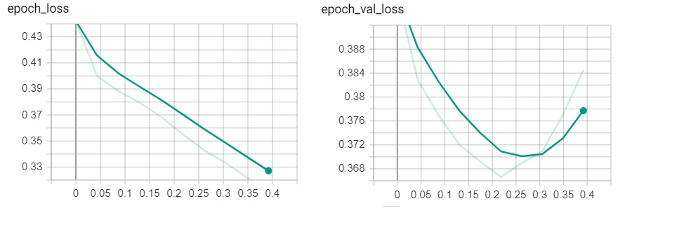

Epoch AUC and Validation AUC

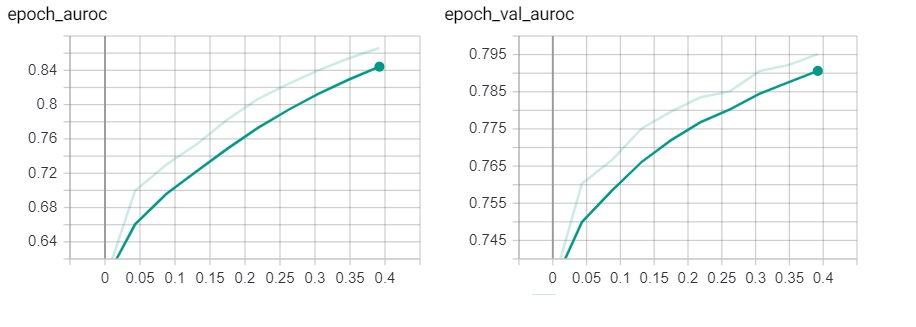

#### Model Prediction

```python
test_set = [test_combine_sequence,test_state_sequence,test_grade_sequence,test_prefix_sequence,test_category_sequence,test_subcategory_sequence,test_numerical]
```

AUC Score

```python
#generator = data_generator(y_test,1,1,batch_size)
history = model.predict(test_set)


# converting probabilistic values to class label. Threshold = 0.5
y_pred = (history > 0.7).astype(np.int)


print("AUC score is {}".format(roc_auc_score(y_test,y_pred)))
```

```
AUC score is 0.7073105970217028
```

**Confusion Matrix**

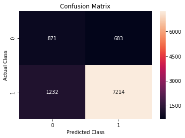

```python
from sklearn.metrics import confusion_matrix
cm1 = confusion_matrix(y_test,y_pred)
# https://seaborn.pydata.org/generated/seaborn.heatmap.html
sns.heatmap(cm1, annot=True, fmt="d")
plt.ylabel("Actual Class")
plt.xlabel("Predicted Class")
plt.title("Confusion Matrix")
```

## Model 2

```python
from sklearn.feature_extraction.text import TfidfVectorizer
tfidf = TfidfVectorizer(min_df=10)
combine_tfidf = tfidf.fit_transform(preprocessed_combine)

# converting to dictionary
combine_dict = dict(zip(tfidf.get_feature_names(),list(tfidf.idf_)))
```

```python
from collections import Counter
cnt =  Counter(list(tfidf.idf_))

cnt_idf = dict()
for k,v in cnt.items():
    cnt_idf[v] = k
```

```python
# getting key and values in list
x = []
y = []

for k,v in cnt.items():
    x.append(k)
    y.append(v)

# converting to dataframe
df = pd.DataFrame(data=x,columns=["idf_values"])
df["count"] = y
```

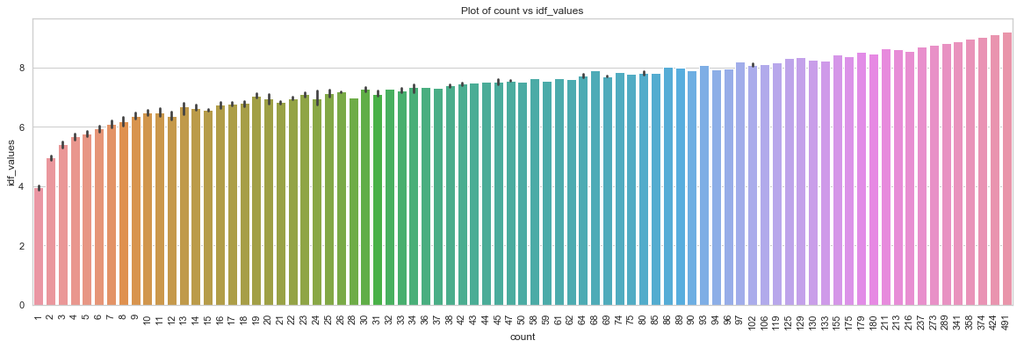

```python
sns.set(style="whitegrid")
plt.figure(figsize=(20,6))
sns.barplot(x = "count",y = "idf_values",data=df,)
plt.xticks(rotation='vertical',)
plt.title("Plot of count vs idf_values")
```

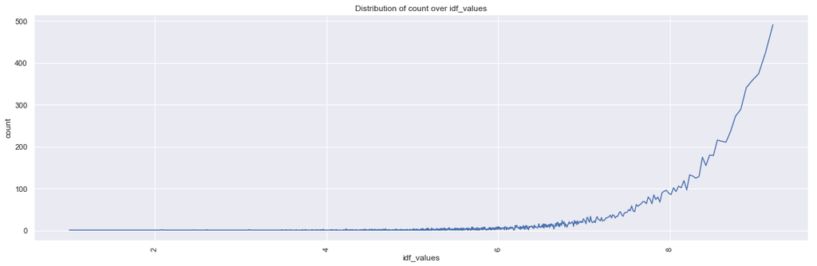

```python
# plotting idf_ values count
sns.set(style="darkgrid")
plt.figure(figsize=(20,6))
sns.lineplot(x="idf_values",y ="count" ,data=df,markers=True, dashes=False,)
plt.xticks(rotation='vertical')
plt.title("Distribution of count over idf_values")
```

1. Idf values plot is skewed towards left.
2. Approx. idf_values greater than 8.5 occur more than 100 times.

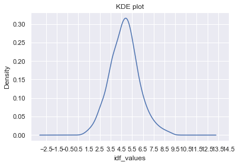

```python
# kde for idf_values
df["idf_values"].plot.kde()
plt.xticks(np.arange(-2.5,15,1.0))
plt.xlabel("idf_values")
plt.title("KDE plot")
plt.figure(figsize=(8,6))
```

From above plot we can see that

1. 10% of idf_ values lie below 3.0
2. **10-90 %** of idf_values lie in between range of 3.0 to 7.0

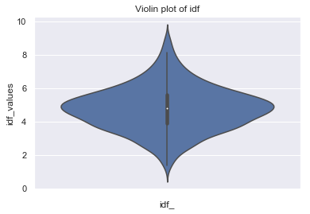

```python
sns.violinplot(x = "idf_values",data=df,orient="v")
plt.xlabel("idf_")
plt.title("Violin plot of idf")
```

We will consider idf*values from 3.0 to 7.0 for our model. Remoove all idf* values from essay_dict

```python
combine_dict
```

[output not shown]

[output cut: 946 more lines]

[output not shown]

```python
for k in list(combine_dict):
    if combine_dict[k] <= 3 or combine_dict[k] >= 7:
        combine_dict.pop(k,None)
```

```python
print("We hvae {} number of features after preprocesing..".format(len(combine_dict)))
```

```
We hvae 3729 number of features after preprocesing..
```

```python
# sorting combine_dict according to k:v  where key is feature name and value is index given
combine_dict = dict(sorted(combine_dict.items(), key=lambda kv: kv[1],reverse = True))
#combine_dict_n = dict()

# assigning integers to keys as per their idf_ values
n = 1
for k in list(combine_dict):
    combine_dict[k] = n
    n += 1
```

```python
combine_dict["start_seq"] = 0
```

```python
# from sklearn.feature_extraction.text import CountVectorizer
# cnt  = CountVectorizer(vocabulary=combine_dict_n)

# combine_idf = cnt.fit_transform(preprocessed_combine)
# test_combine_idf = cnt.transform(test_preprocessed_combine)

# print(combine_idf.shape)
# print(test_combine_idf.shape)
```

```python
len(combine_dict)
```

```
3730
```

```python
combine_sequence_idf = []

for el in preprocessed_combine:
    seq = [combine_dict[word] for word in el.split(' ') if word in combine_dict]
    combine_sequence_idf.append(seq)


# for val data

val_combine_sequence_idf = []

for el in val_preprocessed_combine:
    seq = [combine_dict[word] for word in el.split(' ') if word in combine_dict]
    val_combine_sequence_idf.append(seq)


# for test data

test_combine_sequence_idf = []

for el in test_preprocessed_combine:
    seq = [combine_dict[word] for word in el.split(' ') if word in combine_dict]
    test_combine_sequence_idf.append(seq)
```

- Max_len = 206

```python
Max_len = 206

combine_sequence = pad_sequences(combine_sequence_idf,maxlen=Max_len,padding="post")

# for test and val data

val_combine_sequence = pad_sequences(val_combine_sequence_idf,maxlen=Max_len,padding="post")
test_combine_sequence = pad_sequences(test_combine_sequence_idf,maxlen=Max_len,padding="post")
```

```python
print("shape of combine sequence idf {}".format(combine_sequence.shape))
print("shape of tval combine sequence idf {}".format(val_combine_sequence.shape))
print("shape of test combine sequence idf {}".format(test_combine_sequence.shape))
print("Maximum words are = {}".format(combine_sequence.shape[1]))
```

```
shape of combine sequence idf (40000, 206)
shape of tval combine sequence idf (10000, 206)
shape of test combine sequence idf (10000, 206)
Maximum words are = 206
```

```python
MAX_LENGTH = Max_len
MAX_WORDS = len(combine_dict)

print(MAX_LENGTH)
print(MAX_WORDS)
```

```
206
3730
```

```python
word_to_ix = combine_dict
ix_to_word = dict()
```

```python
for k,v in word_to_ix.items():
    ix_to_word[v] = k

print(len(word_to_ix))
print(len(ix_to_word))
```

```
3730
3730
```

```python
MAX_LENGTH = combine_sequence.shape[1]
print("Maximum sequence length is {}".format(MAX_LENGTH))
print(combine_sequence.shape)
```

```
Maximum sequence length is 206
(40000, 206)
```

```python
# make sure you have the glove_vectors file
with open('glove_vectors', 'rb') as f:
    glove = load(f)
    glove_words =  set(glove.keys())


EMBEDDING_SIZE = 300
VOCAB_SIZE = MAX_WORDS

# Get 300-dim dense vector for each of the words in vocabulary
embedding_matrix_2 = np.zeros((VOCAB_SIZE,EMBEDDING_SIZE))
embedding_matrix_2.shape
```

```
(3730, 300)
```

```python
# code for embedding matrix. considering top 5000 words and using already present glove vectors

# Get 300-dim dense vector for each of the words in vocabulary
embedding_matrix_2 = np.zeros(((VOCAB_SIZE),EMBEDDING_SIZE))

for word, i in word_to_ix.items():
    embedding_vector = np.zeros(300)
    if word in glove_words:
        embedding_vector = glove[word]
        embedding_matrix_2[i] = embedding_vector
    else:
        # Words not found in the embedding index will be all zeros
        embedding_matrix_2[i] = embedding_vector

print("Shape of embedding matrix {}".format(embedding_matrix_2.shape))
```

```
Shape of embedding matrix (3730, 300)
```

**Model Preperation**

```python
# save the embedding matrix to file
with open("embedding_matrix_2_idf.pkl","wb") as f:
    dump(embedding_matrix_2,f)

# functional api for combine
LSTM_UINTS = 8

input_ess = Input(shape=(MAX_LENGTH,))
em1 = Embedding(MAX_WORDS,EMBEDDING_SIZE,input_length=MAX_LENGTH)(input_ess)
lstm = LSTM(LSTM_UINTS,input_shape = (1,MAX_LENGTH), return_sequences=True,)(em1)
flt_ess  = Flatten()(lstm)
```

```python
cnt = concatenate([flt_ess,flt_ss,flt_gc,flt_tp,flt_pc,flt_psc,d_nf])

dense = Dense(8,activation="relu")(cnt)

# dropout + dense
dp = Dropout(0.2)(dense)
dense2 = Dense(4,activation="relu")(dp)

# dropout + dense

dp = Dropout(0.2)(dense2)
dense3 = Dense(2,activation="relu")(dp)

output = Dense(1,activation="sigmoid")(dense3)
```

```python
# input sequence essay + school_state + grade + teacher_prefix + category + sub_categpry + numerical
model = Model(inputs =[input_ess,input_ss,input_gc,input_tp,input_pc,input_psc,input_nf],outputs = output)
```

```python
# Freezing essay embedding_layer from training

model.layers[1].set_weights([embedding_matrix_2])
model.layers[1].trainable = False
```

```python
model.summary()
```

```
__________________________________________________________________________________________________
Layer (type)                    Output Shape         Param #     Connected to
==================================================================================================
input_8 (InputLayer)            (None, 206)          0
__________________________________________________________________________________________________
embedding_7 (Embedding)         (None, 206, 300)     1119000     input_8[0][0]
__________________________________________________________________________________________________
input_6 (InputLayer)            (None, 1)            0
__________________________________________________________________________________________________
input_5 (InputLayer)            (None, 1)            0
__________________________________________________________________________________________________
input_4 (InputLayer)            (None, 1)            0
__________________________________________________________________________________________________
input_2 (InputLayer)            (None, 3)            0
__________________________________________________________________________________________________
input_3 (InputLayer)            (None, 3)            0
__________________________________________________________________________________________________
lstm_2 (LSTM)                   (None, 206, 8)       9888        embedding_7[0][0]
__________________________________________________________________________________________________
embedding_6 (Embedding)         (None, 1, 10)        520         input_6[0][0]
__________________________________________________________________________________________________
embedding_5 (Embedding)         (None, 1, 10)        50          input_5[0][0]
__________________________________________________________________________________________________
embedding_4 (Embedding)         (None, 1, 10)        60          input_4[0][0]
__________________________________________________________________________________________________
embedding_2 (Embedding)         (None, 3, 10)        100         input_2[0][0]
__________________________________________________________________________________________________
embedding_3 (Embedding)         (None, 3, 10)        310         input_3[0][0]
__________________________________________________________________________________________________
input_7 (InputLayer)            (None, 3)            0
__________________________________________________________________________________________________
flatten_7 (Flatten)             (None, 1648)         0           lstm_2[0][0]
__________________________________________________________________________________________________
flatten_6 (Flatten)             (None, 10)           0           embedding_6[0][0]
__________________________________________________________________________________________________
flatten_5 (Flatten)             (None, 10)           0           embedding_5[0][0]
__________________________________________________________________________________________________
flatten_4 (Flatten)             (None, 10)           0           embedding_4[0][0]
__________________________________________________________________________________________________
flatten_2 (Flatten)             (None, 30)           0           embedding_2[0][0]
```

[output cut: 14 more lines]

```
__________________________________________________________________________________________________
dropout_3 (Dropout)             (None, 8)            0           dense_6[0][0]
__________________________________________________________________________________________________
dense_7 (Dense)                 (None, 4)            36          dropout_3[0][0]
__________________________________________________________________________________________________
dropout_4 (Dropout)             (None, 4)            0           dense_7[0][0]
__________________________________________________________________________________________________
dense_8 (Dense)                 (None, 2)            10          dropout_4[0][0]
__________________________________________________________________________________________________
dense_9 (Dense)                 (None, 1)            3           dense_8[0][0]
==================================================================================================
Total params: 1,143,901
Trainable params: 24,901
Non-trainable params: 1,119,000
__________________________________________________________________________________________________
```

```python
# model compilation
model.compile(loss='binary_crossentropy', optimizer='adam',metrics=[auroc])

# using tensorboard instance for callbacks
tensorboard = TensorBoard(log_dir="model2_logs_2/{}".format(time()))
```